# Stroop 2019

Ethan Weed

9/18/2019

You can download the 2019 Stroop data here: kortlink.dk/22tcm

Start by making a new R script, so that you can save your work. Then, enter the following (you can copy and paste this entire block into RStudio. You will only need to change the path to your data).

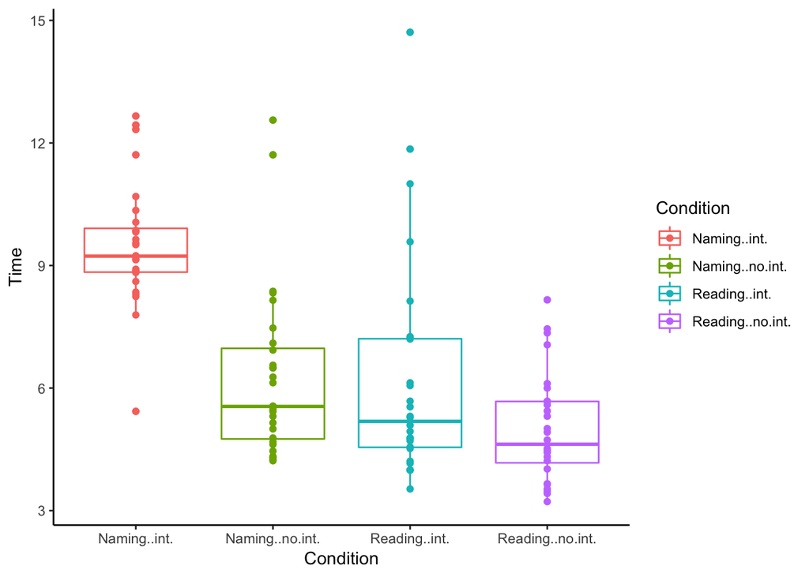

```r
# Load the resources in tidyverse. We will need these for e.g. using ggplot.
library(tidyverse)

# Remove everything from the workspace. That way you won't be tripped up by old data kicking around in your workspace.
rm(list = ls())

# Make a new dataframe with our data.
# Change the path to where your *your* copy is located (probably the downloads folder).
# If you got the data by clicking the link above, it will arrive on your computer in a zip file. You will need to unzip the zip file.
# The file uses a semicolon instead of a comma to separate the columns, so we need use sep = ";" to indicate that
# Use read.csv and *not* read_csv. They look similar, but they are not the same!!
df <- read.csv("/Users/ethan/Desktop/Stroop_2019_a.csv", sep = ";")

# remove unwanted columns.
df$Other.notes. <- NULL
df$Participant.ID <- NULL

# fill out empty cells with 0's, if the participant is not a native Danish speaker
df$Non.native.speaker. <- ifelse(df$Non.native.speaker. == "x", 1, 0)

# make a new dataframe with the data in long format, so that we can plot it.
df_long <- gather(df, key = "Condition", value = "Time", -Non.native.speaker.)

ggplot(df_long, aes(x = Condition, y = Time, color = Condition)) +
  geom_boxplot() +
  geom_point() +
  theme_classic()
```

## Possible solution for question 2: Make a plot with separate plots for all years for which we have Stroop data

If you don’t already have them, you can get the data here: kortlink.dk/22tcp. You will need to unzip the download before you can work with the data.

[figure not shown]

```r
rm(list = ls())
library(tidyverse)
library(ggpubr)
df1 <- read.csv("/Users/ethan/Downloads/Stroop-raw-over-the-years.csv")
df2 <- read.csv("/Users/ethan/Desktop/Stroop_2019_a.csv", sep = ";")
df2 <- plyr::rename(df2, list("Reading..no.int." = "Reading_NoInt",
                        "Naming..int." = "Naming_Int",
                        "Naming..no.int." = "Naming_NoInt",
                        "Reading..int." = "Reading_Int",
                        "Non.native.speaker." = "NNS"))
df2$Other.notes. <- NULL
df2$NNS <- ifelse(df2$NNS == "x", 1, 0)

df1 <- gather(df1, key = "Condition", value = "Time", -Year)
df2 <- gather(subset(df2, NNS == 0), key = "Condition", value = "Time", -Participant.ID, -NNS)


p1 <- ggplot(subset(df1, Year == 2015), aes(x = Condition, y = Time)) +
  geom_boxplot() +
  labs(title = "2015") +
  ylim(3,15) +
  coord_flip()

p2 <- ggplot(subset(df1, Year == 2016), aes(x = Condition, y = Time)) +
  geom_boxplot() +
  labs(title = "2016") +
  ylim(3,15) +
  coord_flip()

p3 <- ggplot(subset(df1, Year == 2017), aes(x = Condition, y = Time)) +
  geom_boxplot() +
  labs(title = "2017") +
  ylim(3,15) +
  coord_flip()

p4 <- ggplot(subset(df1, Year == 2018), aes(x = Condition, y = Time)) +
  geom_boxplot() +
  labs(title = "2018") +
  ylim(3,15) +
  coord_flip()

p5 <- ggplot(df2, aes(x = Condition, y = Time)) +
  geom_boxplot() +
  labs(title = "2019") +
  ylim(3,15) +
  coord_flip()

# and just for fun.....

# install(cowplot)
# install(magick)
library(cowplot)
library(magick)

p6 <- ggdraw() +
  draw_image("https://upload.wikimedia.org/wikipedia/commons/3/3e/Stroop.jpg")


p <- ggarrange(p1, p2, p3, p4, p5, p6, ncol = 2, nrow = 3)
p
```

## Solutions for question 3: Make a plot that compares native and non-native speakers on the 2019 Stroop data.

### Solution 1

Here is one solution for distinguishing between native and non-native speakers. Notice that you need to put a `aes` call in the call to `geom_point()`. This is because the color only applies to the points, not to e.g. the boxplots.

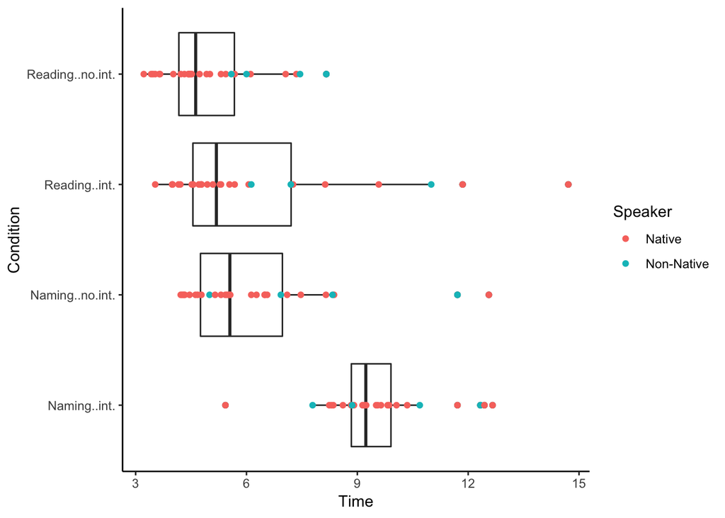

```r
library(tidyverse)

rm(list = ls())

df <- read.csv("/Users/ethan/Desktop/Stroop_2019_a.csv", sep = ";")


df$Other.notes. <- NULL
df$Participant.ID <- NULL

df$Speaker <- as.factor(ifelse(df$Non.native.speaker. == "x", "Non-Native", "Native"))
df$Non.native.speaker. <- NULL


df <- gather(df, key = "Condition", value = "Time", -Speaker)

ggplot(df, aes(x = Condition, y = Time)) +
  geom_boxplot() +
  geom_point(aes(x = Condition, y = Time, color = Speaker)) +
  theme_classic() +
  coord_flip()
```

### Solution 2

Use `color` to make separate boxplots for native and non-native speakers.

There are (at least) two different ways to write the ggplot syntax. Either will produce the same plot.

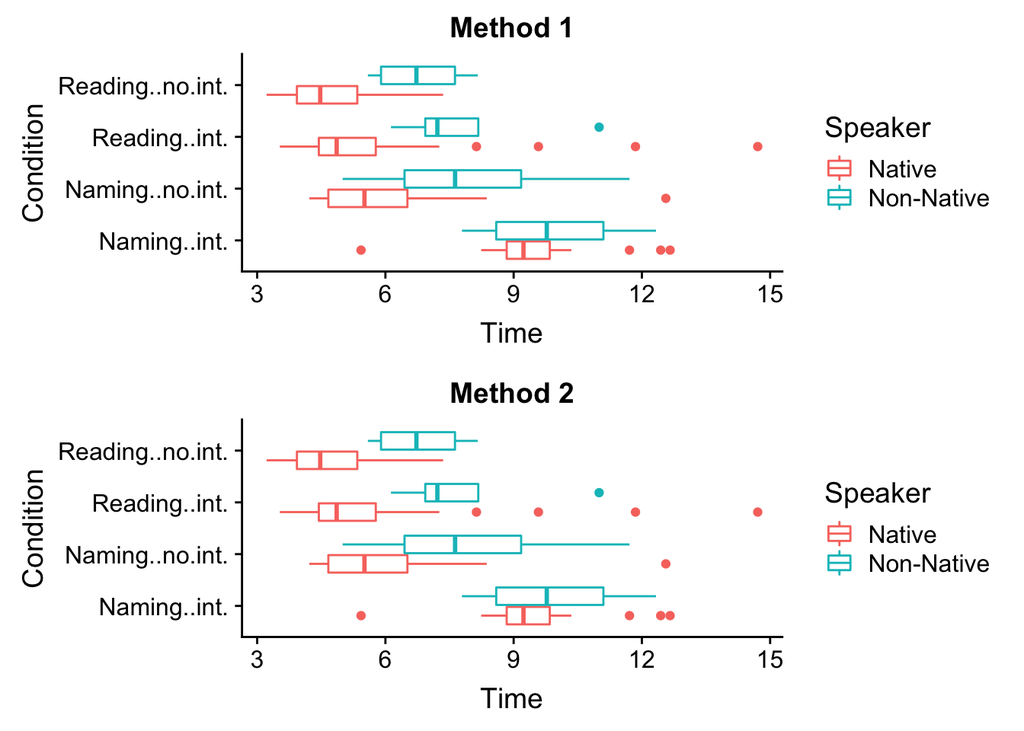

```r
library(tidyverse)
library(ggpubr)

rm(list = ls())

df <- read.csv("/Users/ethan/Desktop/Stroop_2019_a.csv", sep = ";")


df$Other.notes. <- NULL
df$Participant.ID <- NULL

df$Speaker <- as.factor(ifelse(df$Non.native.speaker. == "x", "Non-Native", "Native"))
df$Non.native.speaker. <- NULL


df <- gather(df, key = "Condition", value = "Time", -Speaker)

# method 1
p1 <- ggplot(df) +
  geom_boxplot(aes(x = Condition, y = Time, color = Speaker))+
  coord_flip() +
  labs(title = "Method 1")

# method 2
p2 <- ggplot(df, aes(x = Condition, y = Time, color = Speaker))+
  geom_boxplot() +
  coord_flip() +
  labs(title = "Method 2")


ggarrange(p1, p2, ncol = 1, nrow = 2)
```